# Bio244 - LAB 9 - Two-Way Anova & Interactions

Gabriel Perron

2/25/2019

# Objective

Learning how to use two-way anova to test for multiple explanatory variables,

## Question 1

H<sub>0i</sub>: There is no effect of the interaction betwene soil type and water treatment on shoot length;  
H<sub>Ai</sub>: There is an effect of the interaction betwene soil type and water treatment on shoot length;  
H<sub>01</sub>: There is no effect of soil type on shoot length;  
H<sub>A1</sub>: There is an effect of soil type on shoot length;  
H<sub>02</sub>: There is no effect of water treatment on shoot length;  
H<sub>A</sub>: There is an effect of water treatment on shoot length;

```r
model1 <- lm(RADISH$GREEN~factor(RADISH$SOIL)+factor(RADISH$WATER)+factor(RADISH$SOIL):factor(RADISH$WATER))
anova(model1)
```

```
## Analysis of Variance Table
##
## Response: RADISH$GREEN
##                                          Df  Sum Sq Mean Sq  F value    Pr(>F)
## factor(RADISH$SOIL)                       1    4.20    4.20   0.4063    0.5263
## factor(RADISH$WATER)                      1 1132.32 1132.32 109.4825 3.741e-15
## factor(RADISH$SOIL):factor(RADISH$WATER)  1  200.22  200.22  19.3592 4.513e-05
## Residuals                                60  620.55   10.34
##
## factor(RADISH$SOIL)
## factor(RADISH$WATER)                     ***
## factor(RADISH$SOIL):factor(RADISH$WATER) ***
## Residuals
## ---
## Signif. codes:  0 '***' 0.001 '**' 0.01 '*' 0.05 '.' 0.1 ' ' 1
```

**Conclusion**: There is a significant effect of the interaction betwene soil type and water treatment on shoot length (*F*<sub>(1,60)</sub> = 19.359; *P* < 0.0001).

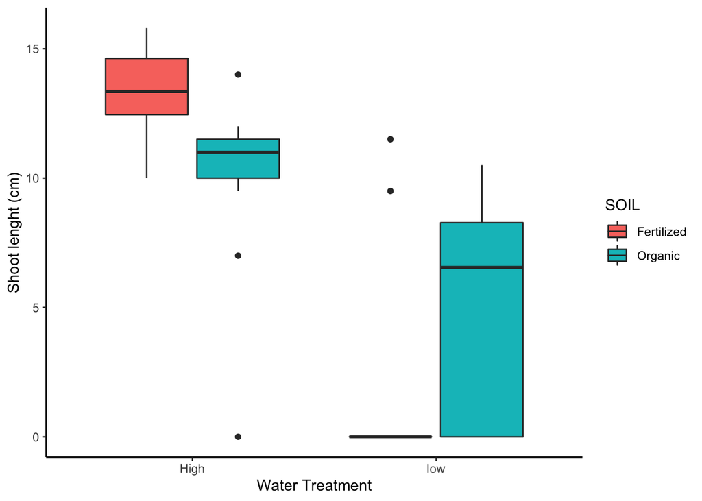

```r
(Figure1 <- ggplot(RADISH, aes(y=GREEN, x=factor(WATER), fill=SOIL)) +
            geom_boxplot() +
            xlab("Water Treatment") +
            ylab("Shoot lenght (cm)")+
            theme_classic())
```

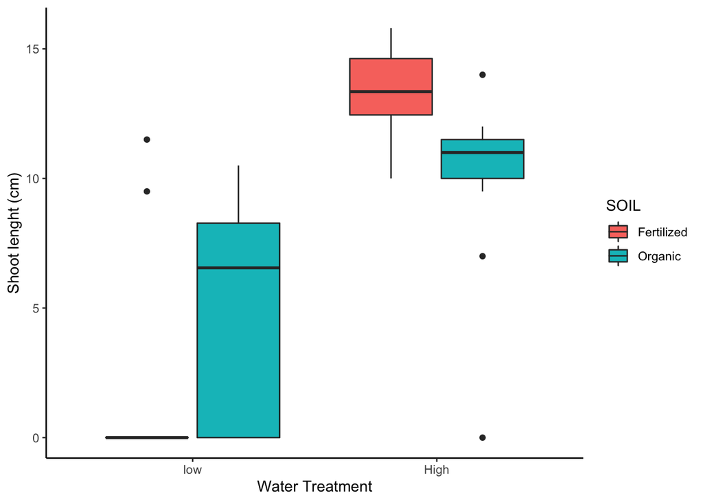

```r
#Now let's order water treatment from low to high on the x-axis
(Figure1_ordered <- ggplot(RADISH, aes(y=GREEN, x=factor(WATER, level = c('low','High')), fill=SOIL)) +
            geom_boxplot() +
            xlab("Water Treatment") +
            ylab("Shoot lenght (cm)")+
            theme_classic())
```

**Figure 1.** There is a significant effect of the interaction betwene soil type and water treatment on shoot length (*F*<sub>(1,60)</sub> = 19.359; *P* < 0.0001).

## Question 2

H0<sub>i</sub>: There is no effect of the interaction betwene soil type and water treatment on root length;  
H<sub>A</sub>: There is an effect of the interaction betwene soil type and water treatment on root length;  
H<sub>01</sub>: There is no effect of soil type on root length;  
H<sub>A1</sub>: There is an effect of soil type on root length;  
H<sub>02</sub>: There is no effect of water treatment on root length;  
H<sub>A2</sub>: There is an effect of water treatment on root length;

```r
model1 <- aov(RADISH$ROOT~factor(RADISH$SOIL)+factor(RADISH$WATER)+factor(RADISH$SOIL):factor(RADISH$WATER))
summary(model1)
```

```
##                                          Df Sum Sq Mean Sq F value   Pr(>F)
## factor(RADISH$SOIL)                       1   81.9   81.90  11.859  0.00105 **
## factor(RADISH$WATER)                      1  219.8  219.78  31.823 4.84e-07 ***
## factor(RADISH$SOIL):factor(RADISH$WATER)  1   13.3   13.32   1.929  0.17000
## Residuals                                60  414.4    6.91
## ---
## Signif. codes:  0 '***' 0.001 '**' 0.01 '*' 0.05 '.' 0.1 ' ' 1
```

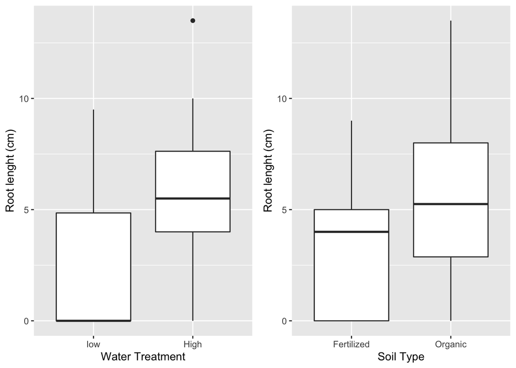

```r
Figure2A <- ggplot(RADISH, aes(x=factor(WATER, level =c('low','High')), y=ROOTS)) +
            geom_boxplot() +
            xlab("Water Treatment") +
            ylab("Root lenght (cm)")
Figure2B <- ggplot(RADISH, aes(x=SOIL, y=ROOTS)) +
            geom_boxplot() +
            xlab("Soil Type") +
            ylab("Root lenght (cm)")

grid.arrange(Figure2A, Figure2B, ncol=2)
```